# Pear microbial communities!

Vera Pfeiffer

September 6, 2019

# Pear flower microbial community project

**Microbial communities** are interesting and diverse. Some are *harmful pathogens* and some *promote good plant health*.

Orchard microbial communities are influenced by *spatial structure* (stochastic processes) and *environmental factors* as well as *farm management* practices (i.e., deterministic processes).

Here we consider the stochastic and deterministic factors that underly both bacterial and fungal community richness and evenness (alpha diversity), and we investigate the influence of these factors on specific microbes of interest in pear cultivation. We also investigate community turnover (beta diversity) across our study extent, and we partition community turnover (beta diversity) to seperately investigate the influence of stochastic and deterministic processes on abundance driven turnover compared to taxa assemblage related turnover.

## Main Messages:

1. Bacteria communities are influenced by farm managment as well as surrounding agricultural land use (Multivariate regression and model selection - % fruit orchard in surrounding landscape)
2. Fungal communities are influenced by farm managment practices as well as environmental variables (Multivariate regression and model selection, vapor pressure deficit - moisture)
3. There is not a strong influence of spatial patterning in our main pathogens and commensals of interest (1st approach - correlograms; 2nd approach - Canonical Correlation Analysis - still working on it to contrast the deterministic and stochastic factor influence on our good and bad bacteria and fungi)
4. Community turnover (whole Bac community as well as Bac community beta diversity partitioned between abundance and genera turnover contributions) was influenced by surrounding forest for CCA, or minimum temperature for bacteria using euclidean distance RDA, but proportion of forest using bray-curtis distance for the whole community RDA… both abundance and taxa turnover were also influneced by surrounding forest (not very spatial…)
5. Community turnover (whole Fungal community as well as fungal community beta diversity partitioned between abundance and genera turnover contributions) was influenced by vapor pressure deficit (moisture) using euclidean distance, and minimum temperature and elevation using bray-curtis distance (very not spatial…). Abundance related turnover was spatially autocorrelated and related to proportion of forest, while taxa related turnover was related to minimum temperature and elevation

## Table of Contents

1 Variable exploration

2 Bacterial community alpha diversity model selection - top multivariate models for Shannon diversity and Simpson dominance (Hyp 1)

3 Fungal community alpha diversity model selection - top multivariate models for Shannon diversity and Simpson dominance (Hyp 2)

4 Correlograms to invesgigate stochastic (spatial) patterning of taxa of interest - not much pattern

5 Canonical Correlation Analysis (extension of linear regression for multiple independent and multiple dependent variables) - second approach investigate influence of factors on good and bad taxa of interest (Hyp 3) (not successful yet - but it should work with some more tinkering)

6 Bacterial community beta diversity RDA or CCA models and model selection (Hyp 4)

7 Fungal community beta diversity RDA or CCA models and model selection (Hyp 5)

## Pear flower microbial community project data analysis

David Crowder’s postdoc Robert Schaeffer collected some data on microbial communities on flowers in pear orchards as part of his work in the Crowder lab. The study looked at microbe communities in the interior and edges of 15 orchards, with variation in management (conventional vs organic).

Here, we are checking out some additional climate and land cover variables to see if they might be able to elucidate relationships between the climate/landscape, as well as farm management and alpha diversity of microbial communities.

Data: This initial dataset includes a number of alpha diversity metrics for each pear orchard, bacteria and fungi separately. Coordinates are given for each, along with management scheme, where the sample was taken (interior or edge of orchard), as well as orchard acreage.

There are a lot of alpha diversity metrics here, so I focus on the “observed” alpha diversity, the Shannon diversity, and the inverse Simpson index, which indicates lack of dominance.

Shannon = combo of richness and evenness Simpson = probability that two entities taken at random represent the same type

## “Let’s check out these alpha diversity stats…”

It seems like ‘observed alpha diversity’, ‘chao1’, ‘ace’, and to a lesser degree ‘fisher’ provide similar information. So we’ll focus on ‘Shannon’ diversity considering richenss and evenness, and the ‘inverse Simpson’ index, describing a lack of dominance in the rest of this analysis.

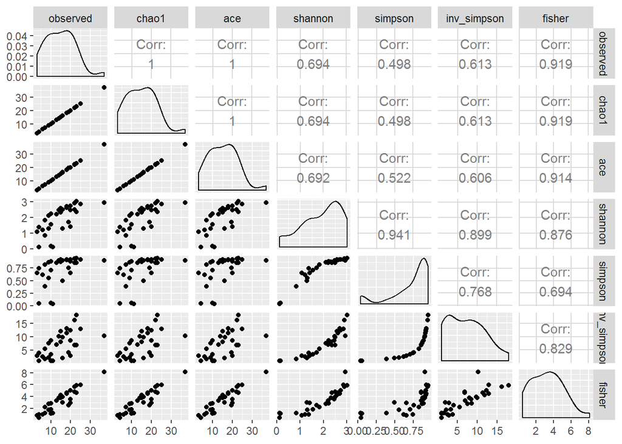

```r
ggpairs(bacAD)
```

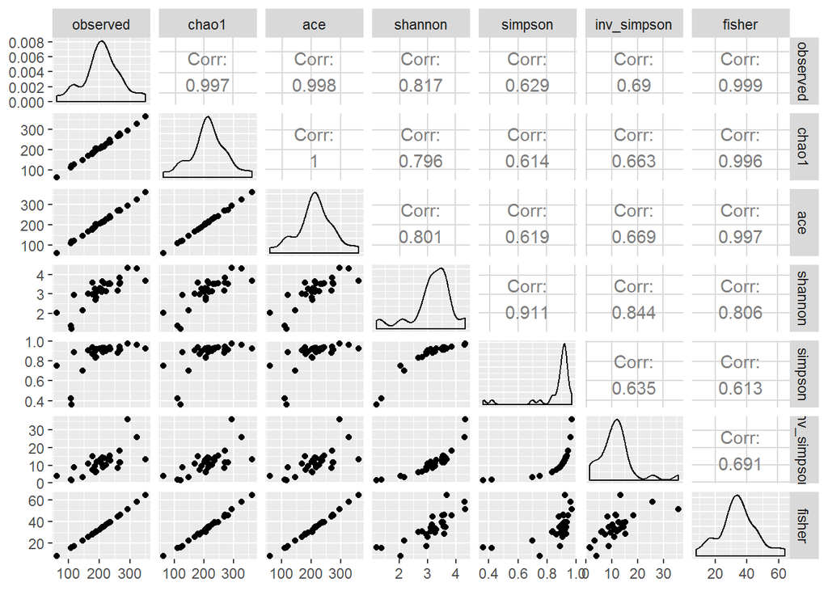

```r
ggpairs(funAD)
```

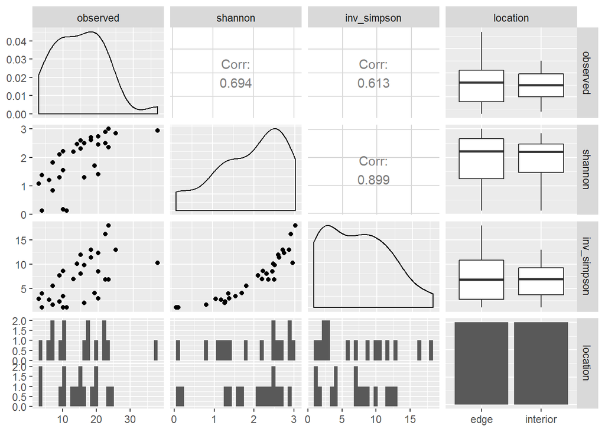

```r
ggpairs(bacLoc)
```

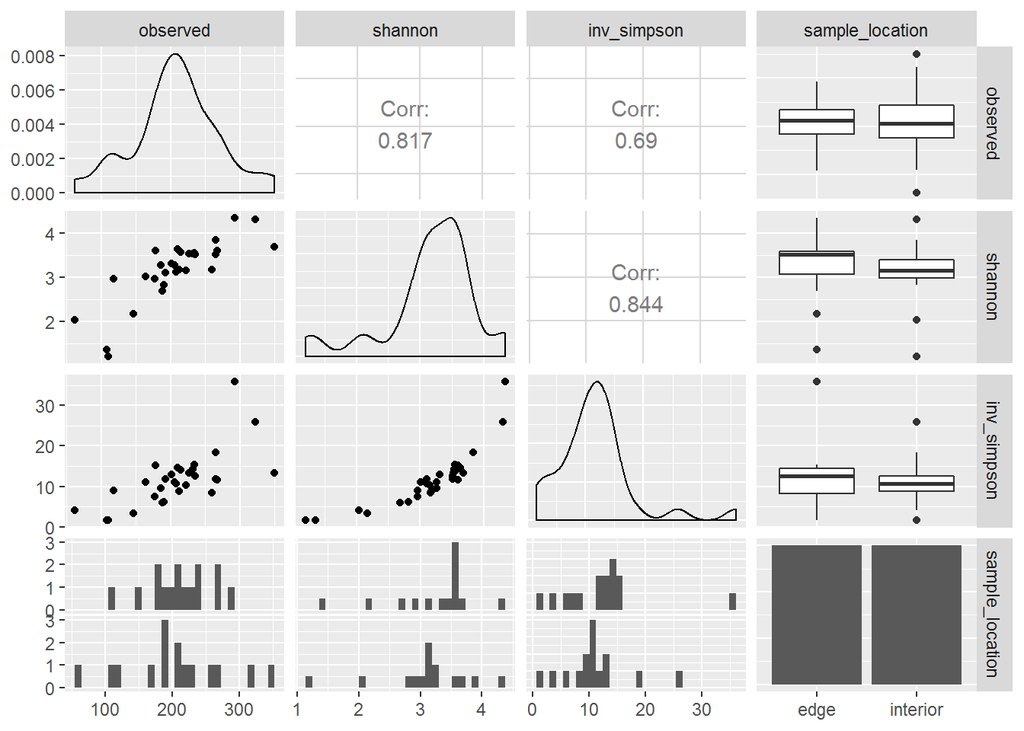

```r
ggpairs(funLoc)
```

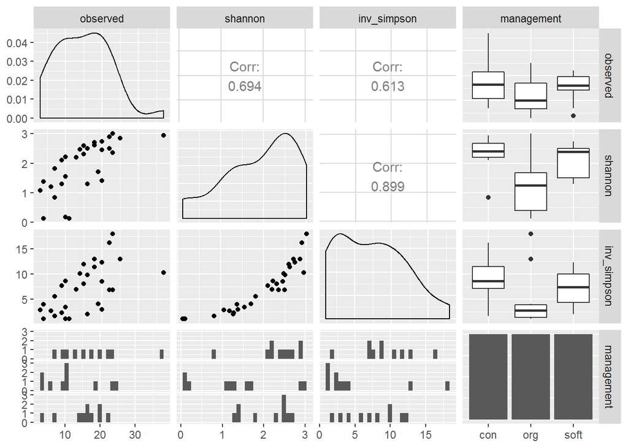

```r
ggpairs(bacMan)
```

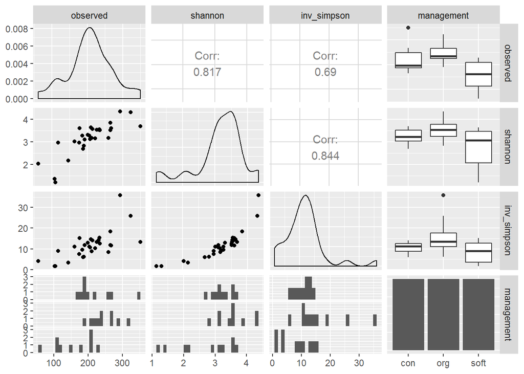

```r
ggpairs(funMan)
```

It looks like the alpha diversity didn’t change much between the edge and interior locations.

It’s interesting that the organic farms seem to have lower bacterial ‘Shannon’ diversity and ‘inverse Simpson’ lack of dominance, while the organic farms may also have a tiny bit higher fungal diversity than especially compared to the soft management.

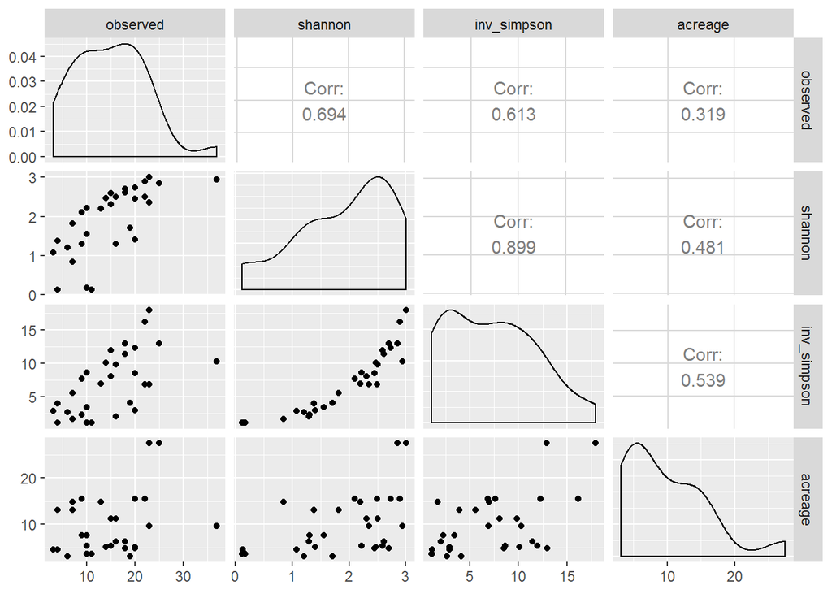

```r
ggpairs(bacAcr)
```

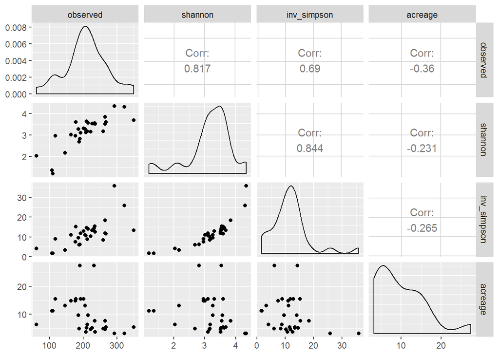

```r
ggpairs(funAcr)
```

## Climate variables

Here are some climate variables for the sites, from Prism data downloaded at a 4km resolution for April 2017. The climate variables include elevation, precipitation, min and max temperature, and min and max VPD. VPD is the difference (deficit) between the amount of moisture in the air and how much moisture the air can hold when it is saturated. So when it’s low, the air is saturated, and once air becomes saturated, water will condense out to form clouds, dew, or films of water over leaves.

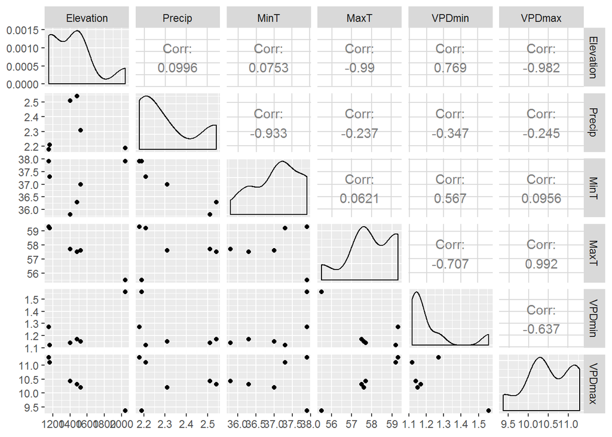

```r
ggpairs(Clim)
```

So it seems the higher sites have lower maximum temps, also lower maximum VPD and higher minimum VPD.

There are a few mid elevation sites with higher precipitation, and lower minimum temperature (perhaps cold air drains? this is just April 2017)

## Landscape variables

Here are three land cover variables extracted in the 500m buffers surrounding sites from the USDA croplands dataset (2017). We focus on pear cultivation, other fruit crops (Cherries and apples combined), and forest cover.

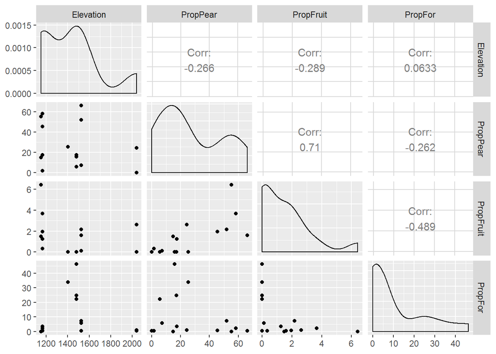

```r
ggpairs(Land)
```

These sites are all in a corridor with extensive pear cultivation. At sites surrounded by more pear cultivation, there’s a higher chance of other fruit crop cultivation (cherries and apples) as well. At sites with more surrounding forest, there is only pear.

## Climate, landscape, and microbe diversity

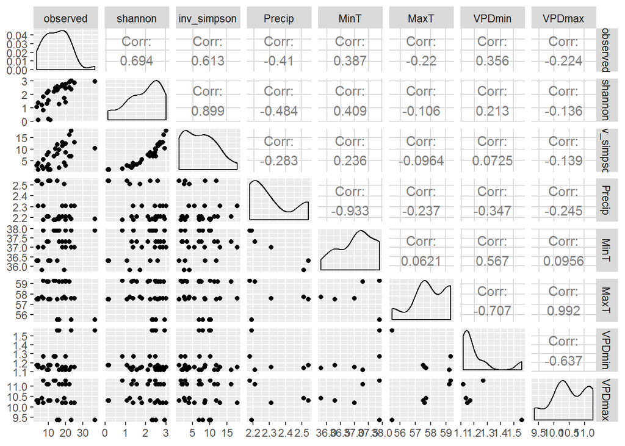

```r
ggpairs(BacClim)
```

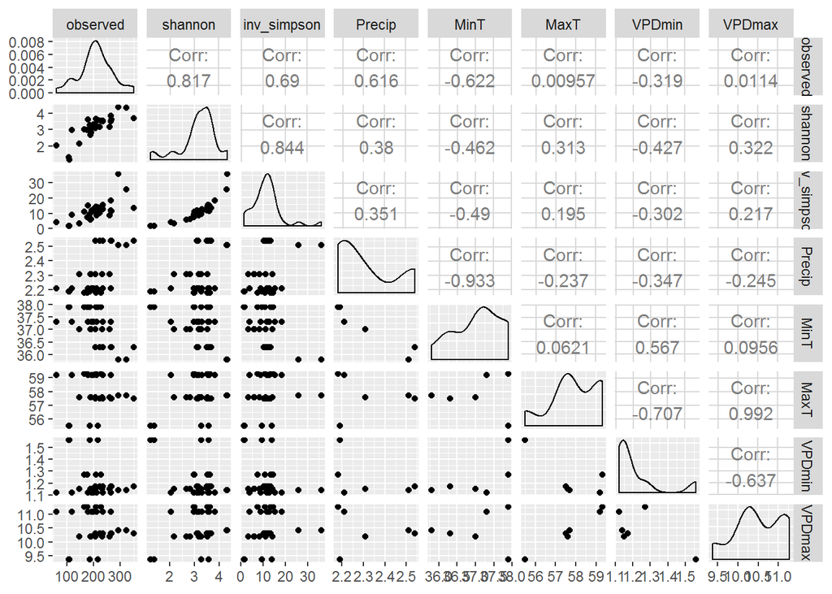

```r
ggpairs(FunClim)
```

also, perhaps there’s higher fungal diversity when there is more precipitation, and higher lower min temps…

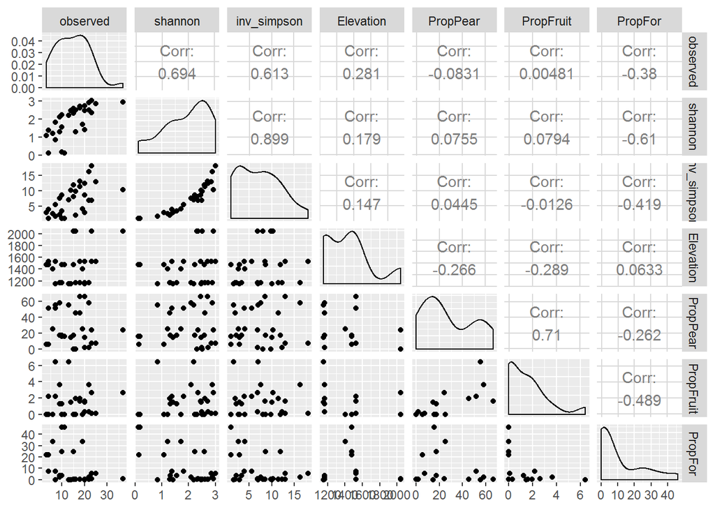

```r
ggpairs(BacLand)
```

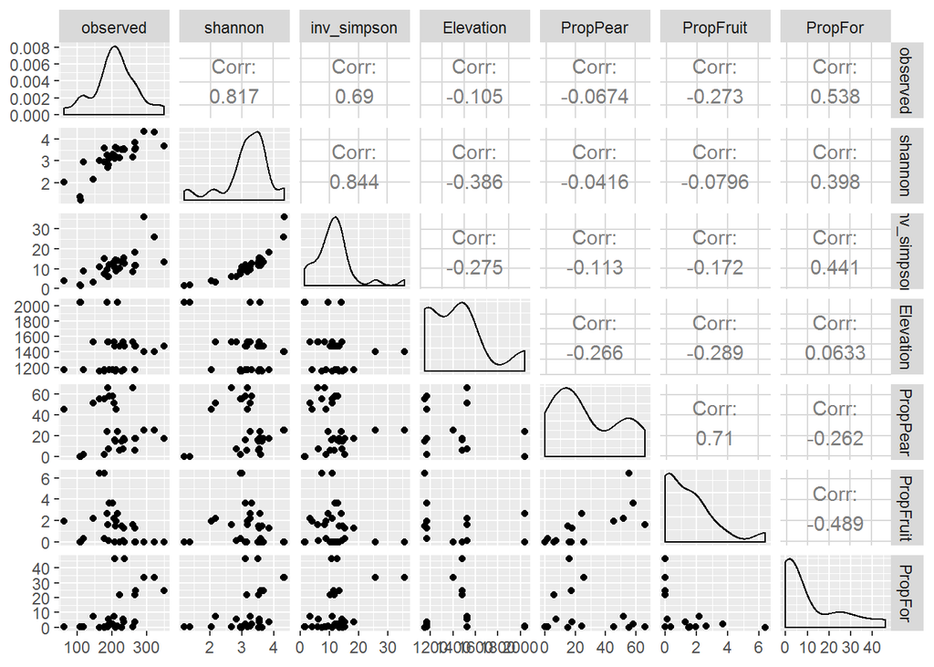

```r
ggpairs(FunLand)
```

Those more forested sites have a bit less bacterial diversity, and a bit more fungal diversity.

## Multiple variate regression models

Now for some multiple regression models that measure the influence of management on Shannon diversity, while controlling for the climate and land cover variables as well.

### Bacterial community shannon diversity models

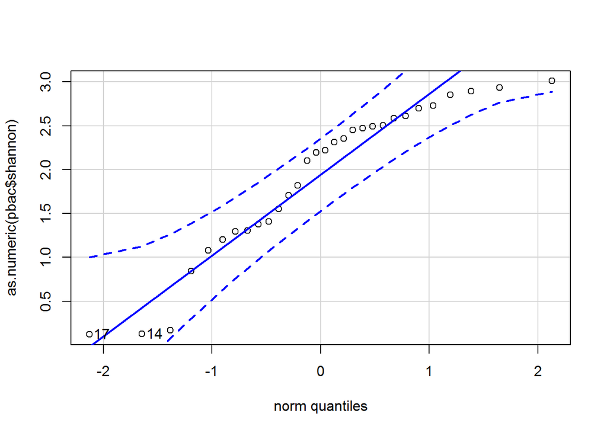

```
## [1] 17 14
```

```r
qqp(as.numeric(pbac$shannon), "norm")
```

```r
mod1<-lm(shannon ~ management + VPDmin + VPDmax + PropFor + PropPear + PropFruit, na.action= "na.fail", data = pbac)
vif(mod1)
```

```
##                GVIF Df GVIF^(1/(2*Df))
## management 4.121054  2        1.424794
## VPDmin     7.100878  1        2.664747
## VPDmax     5.859277  1        2.420594
## PropFor    2.019697  1        1.421160
## PropPear   5.842828  1        2.417194
## PropFruit  7.923633  1        2.814895
```

```r
summary(mod1) #FUll model after VIF elimination
```

```
##
## Call:
## lm(formula = shannon ~ management + VPDmin + VPDmax + PropFor +
##     PropPear + PropFruit, data = pbac, na.action = "na.fail")
##
## Residuals:
##     Min      1Q  Median      3Q     Max
## -1.3335 -0.3325 -0.1078  0.4115  0.9306
##
## Coefficients:
##                 Estimate Std. Error t value Pr(>|t|)
## (Intercept)     9.382177   6.808988   1.378 0.182086
## managementorg  -1.161949   0.409318  -2.839 0.009555 **
## managementsoft -0.853407   0.343633  -2.483 0.021114 *
## VPDmin         -1.832138   2.022645  -0.906 0.374849
## VPDmax         -0.345149   0.428715  -0.805 0.429390
## PropFor        -0.045581   0.010830  -4.209 0.000362 ***
## PropPear       -0.008593   0.012150  -0.707 0.486865
## PropFruit      -0.179053   0.175095  -1.023 0.317608
## ---
## Signif. codes:  0 '***' 0.001 '**' 0.01 '*' 0.05 '.' 0.1 ' ' 1
##
## Residual standard error: 0.5924 on 22 degrees of freedom
## Multiple R-squared:   0.64,  Adjusted R-squared:  0.5254
## F-statistic: 5.586 on 7 and 22 DF,  p-value: 0.0008455
```

```r
stepAIC(mod1)
```

```
## Start:  AIC=-24.72
## shannon ~ management + VPDmin + VPDmax + PropFor + PropPear +
##     PropFruit
##
##              Df Sum of Sq     RSS     AIC
## - PropPear    1    0.1755  7.8961 -26.045
## - VPDmax      1    0.2275  7.9481 -25.848
## - VPDmin      1    0.2879  8.0086 -25.620
## - PropFruit   1    0.3670  8.0876 -25.326
## <none>                     7.7206 -24.719
## - management  2    3.4010 11.1216 -17.769
## - PropFor     1    6.2161 13.9367  -9.000
##
## Step:  AIC=-26.04
## shannon ~ management + VPDmin + VPDmax + PropFor + PropFruit
##
##              Df Sum of Sq     RSS     AIC
## - VPDmax      1    0.0713  7.9674 -27.775
## - VPDmin      1    0.1124  8.0086 -27.620
## <none>                     7.8961 -26.045
## - PropFruit   1    2.3794 10.2756 -20.143
## - management  2    3.2464 11.1425 -19.713
## - PropFor     1    6.4295 14.3257 -10.174
##
## Step:  AIC=-27.78
## shannon ~ management + VPDmin + PropFor + PropFruit
##
##              Df Sum of Sq     RSS     AIC
## - VPDmin      1    0.0414  8.0089 -29.619
## <none>                     7.9674 -27.775
## - management  2    4.1127 12.0801 -19.289
## - PropFruit   1    4.3654 12.3329 -16.668
## - PropFor     1    6.3582 14.3257 -12.174
##
## Step:  AIC=-29.62
## shannon ~ management + PropFor + PropFruit
##
##              Df Sum of Sq     RSS     AIC
## <none>                     8.0089 -29.619
## - management  2    4.1224 12.1312 -21.162
## - PropFruit   1    4.3285 12.3374 -18.657
## - PropFor     1    6.3314 14.3402 -14.144
```

```
##
## Call:
## lm(formula = shannon ~ management + PropFor + PropFruit, data = pbac,
##     na.action = "na.fail")
##
## Coefficients:
##    (Intercept)   managementorg  managementsoft         PropFor
##        3.44554        -1.04279        -0.90827        -0.04522
##      PropFruit
##       -0.30146
```

```r
mod1step<-lm(shannon ~ management + PropFor + PropFruit, na.action= "na.fail", data = pbac)
summary(mod1step)
```

```
##
## Call:
## lm(formula = shannon ~ management + PropFor + PropFruit, data = pbac,
##     na.action = "na.fail")
##
## Residuals:
##     Min      1Q  Median      3Q     Max
## -1.2753 -0.2947 -0.1249  0.3278  0.9003
##
## Coefficients:
##                Estimate Std. Error t value Pr(>|t|)
## (Intercept)     3.44554    0.31778  10.843 6.11e-11 ***
## managementorg  -1.04279    0.33132  -3.147 0.004226 **
## managementsoft -0.90827    0.29793  -3.049 0.005371 **
## PropFor        -0.04522    0.01017  -4.446 0.000157 ***
## PropFruit      -0.30146    0.08201  -3.676 0.001133 **
## ---
## Signif. codes:  0 '***' 0.001 '**' 0.01 '*' 0.05 '.' 0.1 ' ' 1
##
## Residual standard error: 0.566 on 25 degrees of freedom
## Multiple R-squared:  0.6265, Adjusted R-squared:  0.5668
## F-statistic: 10.48 on 4 and 25 DF,  p-value: 3.976e-05
```

```r
modsel<-dredge(mod1,beta = c("none"), rank = "AICc")
```

```
## Fixed term is "(Intercept)"
```

```r
avgcoef<-model.avg(modsel, cumsum(weight) <= .90)
avgcoef
```

```
##
## Call:
## model.avg(object = modsel, subset = cumsum(weight) <= 0.9)
##
## Component models:
## '123'   '1236'  '1235'  '1234'  '23'    '25'    '12356' '2'     '12346'
##
## Coefficients:
##        (Intercept) managementorg managementsoft     PropFor  PropFruit
## full      3.564827    -0.9791007     -0.8494855 -0.04497056 -0.2847076
## subset    3.564827    -1.0474001     -0.9087432 -0.04497056 -0.2970940
##             VPDmin      VPDmax      PropPear
## full   -0.05244841 -0.01160223 -3.758717e-05
## subset -0.35159308 -0.07926617 -3.098873e-04
```

```r
confint(avgcoef, level = 0.90) # Could be 0.95 if 95% confidence intervals preferred
```

```
##                        5 %        95 %
## (Intercept)     1.50677406  5.62287973
## managementorg  -1.63125020 -0.46354992
## managementsoft -1.42939045 -0.38809593
## PropFor        -0.06262822 -0.02731291
## PropFruit      -0.45178619 -0.14240181
## VPDmin         -1.88838459  1.18519843
## VPDmax         -0.51281764  0.35428531
## PropPear       -0.01342090  0.01280113
```

```r
importance(avgcoef)
```

```
##                      PropFor PropFruit management VPDmin VPDmax PropPear
## Sum of weights:      1.00    0.96      0.93       0.15   0.15   0.12
## N containing models:    9       7         6          3      3      2
```

```r
avgcoef<-model.avg(modsel, subset = delta < 4)
avgcoef
```

```
##
## Call:
## model.avg(object = modsel, subset = delta < 4)
##
## Component models:
## '123'  '1236' '1235' '1234'
##
## Coefficients:
##        (Intercept) managementorg managementsoft     PropFor  PropFruit
## full      3.497769     -1.046253     -0.9092651 -0.04527609 -0.3017801
## subset    3.497769     -1.046253     -0.9092651 -0.04527609 -0.3017801
##             VPDmin        VPDmax     PropPear
## full   -0.03487409 -0.0006951743 3.620123e-07
## subset -0.27948334 -0.0060186110 3.135914e-06
```

### Fungal community Shannon diversity models

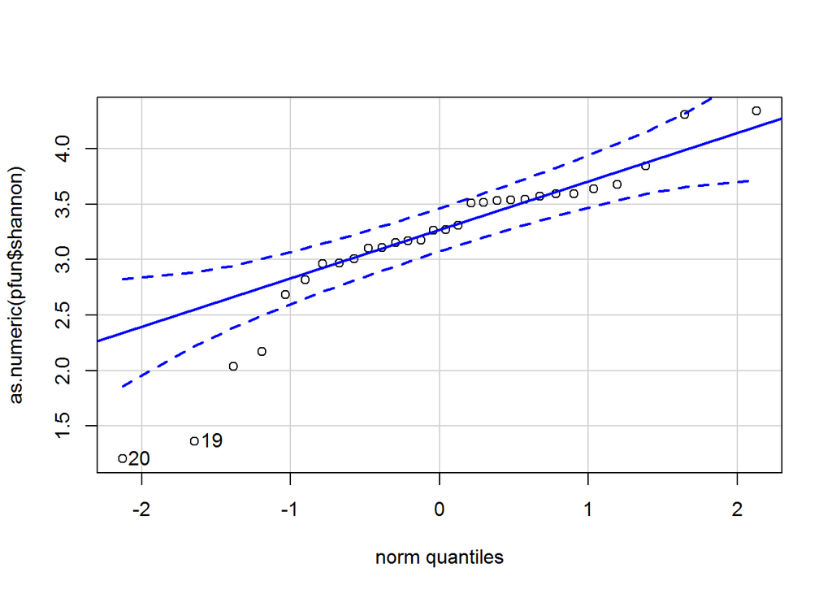

```
## [1] 20 19
```

```r
qqp(as.numeric(pfun$shannon), "norm")
```

```r
mod2<-lm(shannon ~ management + VPDmin + VPDmax + PropFor + PropPear+ PropFruit, na.action= "na.fail", data = pfun)
vif(mod2)
```

```
##                GVIF Df GVIF^(1/(2*Df))
## management 4.121054  2        1.424794
## VPDmin     7.100878  1        2.664747
## VPDmax     5.859277  1        2.420594
## PropFor    2.019697  1        1.421160
## PropPear   5.842828  1        2.417194
## PropFruit  7.923633  1        2.814895
```

```r
summary(mod2)
```

```
##
## Call:
## lm(formula = shannon ~ management + VPDmin + VPDmax + PropFor +
##     PropPear + PropFruit, data = pfun, na.action = "na.fail")
##
## Residuals:
##     Min      1Q  Median      3Q     Max
## -0.9105 -0.3564 -0.1008  0.4105  0.9586
##
## Coefficients:
##                 Estimate Std. Error t value Pr(>|t|)
## (Intercept)    -3.331958   6.724369  -0.496   0.6252
## managementorg  -0.157207   0.404231  -0.389   0.7011
## managementsoft -0.818695   0.339363  -2.412   0.0246 *
## VPDmin          0.180428   1.997508   0.090   0.9288
## VPDmax          0.638170   0.423387   1.507   0.1460
## PropFor         0.010083   0.010696   0.943   0.3561
## PropPear       -0.001773   0.011999  -0.148   0.8839
## PropFruit      -0.107104   0.172919  -0.619   0.5420
## ---
## Signif. codes:  0 '***' 0.001 '**' 0.01 '*' 0.05 '.' 0.1 ' ' 1
##
## Residual standard error: 0.585 on 22 degrees of freedom
## Multiple R-squared:  0.4879, Adjusted R-squared:  0.325
## F-statistic: 2.995 on 7 and 22 DF,  p-value: 0.0229
```

```r
stepAIC(mod2)
```

```
## Start:  AIC=-25.47
## shannon ~ management + VPDmin + VPDmax + PropFor + PropPear +
##     PropFruit
##
##              Df Sum of Sq    RSS     AIC
## - VPDmin      1   0.00279 7.5327 -27.458
## - PropPear    1   0.00747 7.5374 -27.440
## - PropFruit   1   0.13131 7.6612 -26.951
## - PropFor     1   0.30417 7.8341 -26.281
## <none>                    7.5299 -25.469
## - VPDmax      1   0.77762 8.3075 -24.521
## - management  2   2.25498 9.7849 -21.611
##
## Step:  AIC=-27.46
## shannon ~ management + VPDmax + PropFor + PropPear + PropFruit
##
##              Df Sum of Sq     RSS     AIC
## - PropPear    1   0.04216  7.5749 -29.291
## - PropFruit   1   0.24894  7.7817 -28.483
## - PropFor     1   0.30242  7.8351 -28.277
## <none>                     7.5327 -27.458
## - management  2   2.48670 10.0194 -22.900
## - VPDmax      1   2.93967 10.4724 -19.574
##
## Step:  AIC=-29.29
## shannon ~ management + VPDmax + PropFor + PropFruit
##
##              Df Sum of Sq     RSS     AIC
## - PropFor     1   0.27223  7.8471 -30.232
## - PropFruit   1   0.47080  8.0457 -29.482
## <none>                     7.5749 -29.291
## - management  2   2.45307 10.0279 -24.875
## - VPDmax      1   2.90219 10.4771 -21.560
##
## Step:  AIC=-30.23
## shannon ~ management + VPDmax + PropFruit
##
##              Df Sum of Sq     RSS     AIC
## <none>                     7.8471 -30.232
## - PropFruit   1    0.8679  8.7150 -29.085
## - VPDmax      1    2.9579 10.8050 -22.636
## - management  2    4.6227 12.4698 -20.337
```

```
##
## Call:
## lm(formula = shannon ~ management + VPDmax + PropFruit, data = pfun,
##     na.action = "na.fail")
##
## Coefficients:
##    (Intercept)   managementorg  managementsoft          VPDmax
##       -2.66623        -0.05269        -0.88009         0.60444
##      PropFruit
##       -0.14507
```

```r
mod2step<-lm(shannon ~ management + VPDmax + PropFruit, na.action= "na.fail", data = pfun)
summary(mod2step)
```

```
##
## Call:
## lm(formula = shannon ~ management + VPDmax + PropFruit, data = pfun,
##     na.action = "na.fail")
##
## Residuals:
##      Min       1Q   Median       3Q      Max
## -0.91380 -0.33499 -0.04917  0.43007  0.96404
##
## Coefficients:
##                Estimate Std. Error t value Pr(>|t|)
## (Intercept)    -2.66623    1.94890  -1.368  0.18346
## managementorg  -0.05269    0.33849  -0.156  0.87755
## managementsoft -0.88009    0.29956  -2.938  0.00701 **
## VPDmax          0.60444    0.19690   3.070  0.00510 **
## PropFruit      -0.14507    0.08725  -1.663  0.10884
## ---
## Signif. codes:  0 '***' 0.001 '**' 0.01 '*' 0.05 '.' 0.1 ' ' 1
##
## Residual standard error: 0.5603 on 25 degrees of freedom
## Multiple R-squared:  0.4664, Adjusted R-squared:  0.381
## F-statistic: 5.462 on 4 and 25 DF,  p-value: 0.002661
```

```r
modsel2<-dredge(mod2, beta = c("none"), rank = "AICc")
```

```
## Fixed term is "(Intercept)"
```

```r
avgcoef2<-model.avg(modsel2, cumsum(weight) <= .90)
avgcoef2
```

```
##
## Call:
## model.avg(object = modsel2, subset = cumsum(weight) <= 0.9)
##
## Component models:
## '15'    '135'   '125'   '25'    '16'    '145'   '1235'  '156'   '146'
## '1245'  '26'    '1345'  '1356'  '1'     '256'   '6'     '1256'  '245'
## '235'   '1456'  '126'   '2'     '136'   '12'    '236'   '46'    '12345'
##
## Coefficients:
##        (Intercept) managementorg managementsoft    VPDmax  PropFruit
## full    -0.3042342    0.06929038     -0.5525685 0.3901768 -0.0344377
## subset  -0.3042342    0.08734443     -0.6965438 0.5017524 -0.1190409
##            PropFor     VPDmin      PropPear
## full   0.006534998 -0.3758793 -0.0009980656
## subset 0.016169003 -1.2799741 -0.0053895298
```

```r
confint(avgcoef2, level = 0.90) # Could be 0.95 if 95% confidence intervals preferred
```

```
##                         5 %         95 %
## (Intercept)    -6.448986004  5.840517547
## managementorg  -0.518048011  0.692736878
## managementsoft -1.230156275 -0.162931380
## VPDmax          0.132741767  0.870762960
## PropFruit      -0.295093594  0.057011827
## PropFor        -0.001813739  0.034151746
## VPDmin         -3.403958497  0.844010200
## PropPear       -0.017775062  0.006996003
```

```r
importance(avgcoef2)
```

```
##                      management VPDmax PropFor VPDmin PropFruit PropPear
## Sum of weights:      0.79       0.78   0.40    0.29   0.29      0.19
## N containing models:   18         16     14      13      8         8
```

```r
avgcoef2<-model.avg(modsel2, subset = delta < 4)
avgcoef2
```

```
##
## Call:
## model.avg(object = modsel2, subset = delta < 4)
##
## Component models:
## '15'   '135'  '125'  '25'   '16'   '145'  '1235' '156'  '146'  '1245'
## '26'   '1345' '1356' '1'
##
## Coefficients:
##        (Intercept) managementorg managementsoft    VPDmax   PropFruit
## full    -0.7569026    0.08150396     -0.6151174 0.4250024 -0.04148459
## subset  -0.7569026    0.09329375     -0.7040960 0.5111113 -0.13937748
##            PropFor     VPDmin      PropPear
## full   0.005349365 -0.2739936 -0.0009462642
## subset 0.015768777 -1.2756621 -0.0057172637
```

These alpha diversity multivariate linear model results seem to represent the trends we could see in the scatter plots well…

### Bacterial community Simpson dominance models

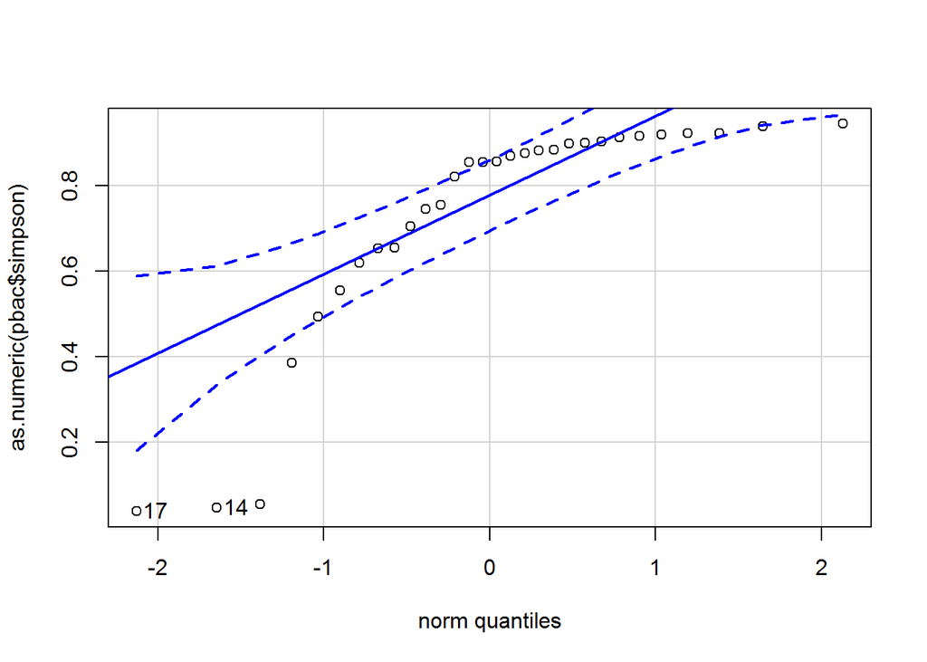

```
## [1] 17 14
```

```r
qqp(as.numeric(pbac$simpson), "norm")
```

```r
#qqp(as.numeric(pbac$simpson), "lnorm")
#nbinom <- fitdistr(as.numeric(pbac$simpson), "Negative Binomial")
#qqp(as.numeric(pbac$simpson), "nbinom", size = nbinom$estimate[[1]], mu = nbinom$estimate[[2]])
```

```r
mod1<-lm(simpson ~ management + VPDmin + VPDmax + PropFor + PropPear + PropFruit, na.action= "na.fail", data = pbac)
vif(mod1)
```

```
##                GVIF Df GVIF^(1/(2*Df))
## management 4.121054  2        1.424794
## VPDmin     7.100878  1        2.664747
## VPDmax     5.859277  1        2.420594
## PropFor    2.019697  1        1.421160
## PropPear   5.842828  1        2.417194
## PropFruit  7.923633  1        2.814895
```

```r
summary(mod1)
```

```
##
## Call:
## lm(formula = simpson ~ management + VPDmin + VPDmax + PropFor +
##     PropPear + PropFruit, data = pbac, na.action = "na.fail")
##
## Residuals:
##      Min       1Q   Median       3Q      Max
## -0.51627 -0.10479  0.02104  0.09976  0.37045
##
## Coefficients:
##                 Estimate Std. Error t value Pr(>|t|)
## (Intercept)     2.913838   2.315344   1.258  0.22141
## managementorg  -0.319224   0.139185  -2.294  0.03174 *
## managementsoft -0.192751   0.116850  -1.650  0.11324
## VPDmin         -0.554930   0.687785  -0.807  0.42840
## VPDmax         -0.104384   0.145781  -0.716  0.48150
## PropFor        -0.013494   0.003683  -3.664  0.00136 **
## PropPear       -0.001329   0.004132  -0.322  0.75074
## PropFruit      -0.052691   0.059540  -0.885  0.38574
## ---
## Signif. codes:  0 '***' 0.001 '**' 0.01 '*' 0.05 '.' 0.1 ' ' 1
##
## Residual standard error: 0.2014 on 22 degrees of freedom
## Multiple R-squared:  0.5801, Adjusted R-squared:  0.4465
## F-statistic: 4.342 on 7 and 22 DF,  p-value: 0.003716
```

```r
stepAIC(mod1)
```

```
## Start:  AIC=-89.44
## simpson ~ management + VPDmin + VPDmax + PropFor + PropPear +
##     PropFruit
##
##              Df Sum of Sq     RSS     AIC
## - PropPear    1   0.00420 0.89693 -91.299
## - VPDmax      1   0.02080 0.91353 -90.749
## - VPDmin      1   0.02642 0.91914 -90.565
## - PropFruit   1   0.03178 0.92451 -90.391
## <none>                    0.89273 -89.440
## - management  2   0.22933 1.12206 -86.581
## - PropFor     1   0.54481 1.43754 -77.148
##
## Step:  AIC=-91.3
## simpson ~ management + VPDmin + VPDmax + PropFor + PropFruit
##
##              Df Sum of Sq     RSS     AIC
## - VPDmax      1   0.01823 0.91515 -92.696
## - VPDmin      1   0.03227 0.92919 -92.239
## <none>                    0.89693 -91.299
## - PropFruit   1   0.14259 1.03952 -88.873
## - management  2   0.23993 1.13686 -88.188
## - PropFor     1   0.55629 1.45321 -78.823
##
## Step:  AIC=-92.7
## simpson ~ management + VPDmin + PropFor + PropFruit
##
##              Df Sum of Sq     RSS     AIC
## - VPDmin      1   0.01405 0.92920 -94.239
## <none>                    0.91515 -92.696
## - management  2   0.31294 1.22810 -87.872
## - PropFruit   1   0.31517 1.23032 -85.818
## - PropFor     1   0.54129 1.45644 -80.756
##
## Step:  AIC=-94.24
## simpson ~ management + PropFor + PropFruit
##
##              Df Sum of Sq    RSS     AIC
## <none>                    0.9292 -94.239
## - management  2   0.29899 1.2282 -89.869
## - PropFruit   1   0.30326 1.2325 -87.765
## - PropFor     1   0.52783 1.4570 -82.744
```

```
##
## Call:
## lm(formula = simpson ~ management + PropFor + PropFruit, data = pbac,
##     na.action = "na.fail")
##
## Coefficients:
##    (Intercept)   managementorg  managementsoft         PropFor
##        1.14331        -0.30089        -0.21875        -0.01306
##      PropFruit
##       -0.07979
```

```r
mod1step<-lm(simpson ~ management + PropFor + PropFruit, na.action= "na.fail", data = pbac)
summary(mod1step)
```

```
##
## Call:
## lm(formula = simpson ~ management + PropFor + PropFruit, data = pbac,
##     na.action = "na.fail")
##
## Residuals:
##      Min       1Q   Median       3Q      Max
## -0.50684 -0.11815  0.01803  0.11072  0.35389
##
## Coefficients:
##                 Estimate Std. Error t value Pr(>|t|)
## (Intercept)     1.143308   0.108242  10.563 1.05e-10 ***
## managementorg  -0.300892   0.112854  -2.666 0.013253 *
## managementsoft -0.218752   0.101480  -2.156 0.040934 *
## PropFor        -0.013056   0.003465  -3.768 0.000896 ***
## PropFruit      -0.079794   0.027935  -2.856 0.008501 **
## ---
## Signif. codes:  0 '***' 0.001 '**' 0.01 '*' 0.05 '.' 0.1 ' ' 1
##
## Residual standard error: 0.1928 on 25 degrees of freedom
## Multiple R-squared:  0.5629, Adjusted R-squared:  0.493
## F-statistic:  8.05 on 4 and 25 DF,  p-value: 0.0002582
```

```r
modsel<-dredge(mod1,beta = c("none"), rank = "AICc")
```

```
## Fixed term is "(Intercept)"
```

```r
avgcoef<-model.avg(modsel, cumsum(weight) <= .90)
avgcoef
```

```
##
## Call:
## model.avg(object = modsel, subset = cumsum(weight) <= 0.9)
##
## Component models:
## '123'  '2'    '23'   '25'   '1236' '1234' '256'  '1235' '234'  '235'
## '24'   '26'   '236'  '12'   '245'  '2345' '2356'
##
## Coefficients:
##        (Intercept) managementorg managementsoft     PropFor   PropFruit
## full      1.295134    -0.1390614     -0.1000054 -0.01294847 -0.04602984
## subset    1.295134    -0.2952526     -0.2123296 -0.01294847 -0.06878607
##             VPDmax      VPDmin     PropPear
## full   -0.02370285 -0.04361678 0.0002578753
## subset -0.08971345 -0.24701516 0.0015442050
```

```r
confint(avgcoef, level = 0.90) # Could be 0.95 if 95% confidence intervals preferred
```

```
##                         5 %         95 %
## (Intercept)    -0.027302078  2.617569905
## managementorg  -0.498753491 -0.091751756
## managementsoft -0.395083910 -0.029575195
## PropFor        -0.018751618 -0.007145328
## PropFruit      -0.129090743 -0.008481388
## VPDmax         -0.250946463  0.071519570
## VPDmin         -0.927309598  0.433279279
## PropPear       -0.003032334  0.006120744
```

```r
importance(avgcoef)
```

```
##                      PropFor PropFruit management VPDmax VPDmin PropPear
## Sum of weights:      1.00    0.67      0.47       0.26   0.18   0.17
## N containing models:   17      10         5          7      5      5
```

```r
avgcoef<-model.avg(modsel, subset = delta < 4)
avgcoef
```

```
##
## Call:
## model.avg(object = modsel, subset = delta < 4)
##
## Component models:
## '123'  '2'    '23'   '25'   '1236' '1234' '256'  '1235' '234'
##
## Coefficients:
##        (Intercept) managementorg managementsoft     PropFor   PropFruit
## full      1.288086    -0.1655263     -0.1200843 -0.01304332 -0.05249113
## subset    1.288086    -0.3011636     -0.2184850 -0.01304332 -0.07373640
##             VPDmax      VPDmin     PropPear
## full   -0.02021696 -0.04682346 0.0002611972
## subset -0.09151169 -0.33538102 0.0020536755
```

### Fungal community Simpson dominance models

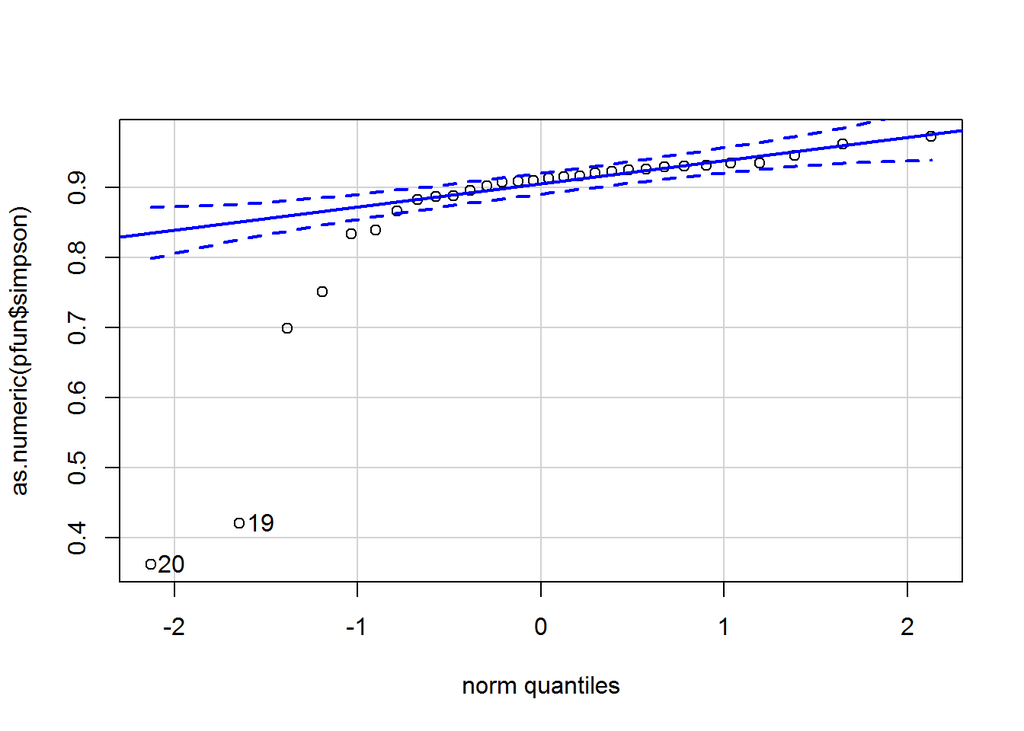

```
## [1] 20 19
```

```r
qqp(as.numeric(pfun$simpson), "norm")
```

```r
#qqp(as.numeric(pfun$simpson), "lnorm")
#nbinom <- fitdistr(as.numeric(pfun$simpson), "Negative Binomial")
#qqp(as.numeric(pfun$simpson), "nbinom", size = nbinom$estimate[[1]], mu = nbinom$estimate[[2]])
```

```r
mod2<-lm(simpson ~ management + VPDmin + VPDmax + PropFor + PropPear+ PropFruit, na.action= "na.fail", data = pfun)
vif(mod2)
```

```
##                GVIF Df GVIF^(1/(2*Df))
## management 4.121054  2        1.424794
## VPDmin     7.100878  1        2.664747
## VPDmax     5.859277  1        2.420594
## PropFor    2.019697  1        1.421160
## PropPear   5.842828  1        2.417194
## PropFruit  7.923633  1        2.814895
```

```r
summary(mod2)
```

```
##
## Call:
## lm(formula = simpson ~ management + VPDmin + VPDmax + PropFor +
##     PropPear + PropFruit, data = pfun, na.action = "na.fail")
##
## Residuals:
##      Min       1Q   Median       3Q      Max
## -0.22107 -0.05259 -0.01252  0.04970  0.20079
##
## Coefficients:
##                 Estimate Std. Error t value Pr(>|t|)
## (Intercept)     0.658229   1.206452   0.546   0.5908
## managementorg  -0.056066   0.072525  -0.773   0.4477
## managementsoft -0.151704   0.060887  -2.492   0.0207 *
## VPDmin         -0.376718   0.358383  -1.051   0.3046
## VPDmax          0.070845   0.075962   0.933   0.3611
## PropFor         0.001376   0.001919   0.717   0.4810
## PropPear       -0.001488   0.002153  -0.691   0.4967
## PropFruit       0.010806   0.031024   0.348   0.7309
## ---
## Signif. codes:  0 '***' 0.001 '**' 0.01 '*' 0.05 '.' 0.1 ' ' 1
##
## Residual standard error: 0.105 on 22 degrees of freedom
## Multiple R-squared:  0.5768, Adjusted R-squared:  0.4421
## F-statistic: 4.283 on 7 and 22 DF,  p-value: 0.004002
```

```r
stepAIC(mod2)
```

```
## Start:  AIC=-128.55
## simpson ~ management + VPDmin + VPDmax + PropFor + PropPear +
##     PropFruit
##
##              Df Sum of Sq     RSS     AIC
## - PropFruit   1  0.001337 0.24372 -130.39
## - PropPear    1  0.005262 0.24765 -129.91
## - PropFor     1  0.005662 0.24805 -129.86
## - VPDmax      1  0.009583 0.25197 -129.39
## - VPDmin      1  0.012174 0.25456 -129.08
## <none>                    0.24239 -128.55
## - management  2  0.070956 0.31334 -124.85
##
## Step:  AIC=-130.39
## simpson ~ management + VPDmin + VPDmax + PropFor + PropPear
##
##              Df Sum of Sq     RSS     AIC
## - PropFor     1  0.004735 0.24846 -131.81
## - PropPear    1  0.005120 0.24884 -131.76
## - VPDmin      1  0.016305 0.26003 -130.44
## <none>                    0.24372 -130.39
## - VPDmax      1  0.042689 0.28641 -127.55
## - management  2  0.100366 0.34409 -124.04
##
## Step:  AIC=-131.81
## simpson ~ management + VPDmin + VPDmax + PropPear
##
##              Df Sum of Sq     RSS     AIC
## - PropPear    1  0.007030 0.25549 -132.97
## <none>                    0.24846 -131.81
## - VPDmin      1  0.025429 0.27389 -130.89
## - VPDmax      1  0.037956 0.28641 -129.55
## - management  2  0.129647 0.37811 -123.21
##
## Step:  AIC=-132.97
## simpson ~ management + VPDmin + VPDmax
##
##              Df Sum of Sq     RSS     AIC
## <none>                    0.25549 -132.97
## - VPDmin      1  0.018717 0.27420 -132.85
## - VPDmax      1  0.039126 0.29461 -130.70
## - management  2  0.122618 0.37811 -125.21
```

```
##
## Call:
## lm(formula = simpson ~ management + VPDmin + VPDmax, data = pfun,
##     na.action = "na.fail")
##
## Coefficients:
##    (Intercept)   managementorg  managementsoft          VPDmin
##       0.358601       -0.004391       -0.143857       -0.257539
##         VPDmax
##       0.082615
```

```r
mod2step<-lm(simpson ~ management + VPDmin + VPDmax, na.action= "na.fail", data = pfun)
summary(mod2step)
```

```
##
## Call:
## lm(formula = simpson ~ management + VPDmin + VPDmax, data = pfun,
##     na.action = "na.fail")
##
## Residuals:
##       Min        1Q    Median        3Q       Max
## -0.225015 -0.061981  0.003339  0.044730  0.197816
##
## Coefficients:
##                 Estimate Std. Error t value Pr(>|t|)
## (Intercept)     0.358601   0.631454   0.568  0.57517
## managementorg  -0.004391   0.049168  -0.089  0.92955
## managementsoft -0.143857   0.045546  -3.159  0.00411 **
## VPDmin         -0.257539   0.190301  -1.353  0.18806
## VPDmax          0.082615   0.042222   1.957  0.06164 .
## ---
## Signif. codes:  0 '***' 0.001 '**' 0.01 '*' 0.05 '.' 0.1 ' ' 1
##
## Residual standard error: 0.1011 on 25 degrees of freedom
## Multiple R-squared:  0.5539, Adjusted R-squared:  0.4825
## F-statistic:  7.76 on 4 and 25 DF,  p-value: 0.0003287
```

```r
modsel2<-dredge(mod2, beta = c("none"), rank = "AICc")
```

```
## Fixed term is "(Intercept)"
```

```r
avgcoef2<-model.avg(modsel2, cumsum(weight) <= .90)
avgcoef2
```

```
##
## Call:
## model.avg(object = modsel2, subset = cumsum(weight) <= 0.9)
##
## Component models:
## '15'   '156'  '125'  '135'  '16'   '145'  '1456' '1256' '1356' '1235'
## '146'  '136'  '1346' '1245' '1345' '6'    '126'  '25'   '236'
##
## Coefficients:
##        (Intercept) managementorg managementsoft     VPDmax     VPDmin
## full     0.1429202  -0.008741135     -0.1430929 0.09316758 -0.1692495
## subset   0.1429202  -0.009126263     -0.1493975 0.11591166 -0.3840567
##             PropFor    PropFruit      PropPear
## full   0.0004231705 -0.001378739 -0.0001319341
## subset 0.0018517192 -0.006119262 -0.0007657490
```

```r
confint(avgcoef2, level = 0.90) # Could be 0.95 if 95% confidence intervals preferred
```

```
##                         5 %        95 %
## (Intercept)    -1.329860598  1.61570096
## managementorg  -0.111056316  0.09280379
## managementsoft -0.237416271 -0.06137877
## VPDmax          0.044353471  0.18746985
## VPDmin         -0.778179223  0.01006589
## PropFor        -0.001338242  0.00504168
## PropFruit      -0.045149078  0.03291055
## PropPear       -0.003405428  0.00187393
```

```r
importance(avgcoef2)
```

```
##                      management VPDmax VPDmin PropFor PropFruit PropPear
## Sum of weights:      0.96       0.80   0.44   0.23    0.23      0.17
## N containing models:   16         12     11      7       7         6
```

```r
avgcoef2<-model.avg(modsel2, subset = delta < 4)
avgcoef2
```

```
##
## Call:
## model.avg(object = modsel2, subset = delta < 4)
##
## Component models:
## '15'   '156'  '125'  '135'  '16'   '145'  '1456' '1256'
##
## Coefficients:
##        (Intercept) managementorg managementsoft    VPDmax     VPDmin
## full   -0.01011332  -0.003843768     -0.1492005 0.1026833 -0.1253368
## subset -0.01011332  -0.003843768     -0.1492005 0.1144022 -0.3309992
##             PropFor   PropFruit      PropPear
## full   0.0003380079 -0.00207066 -6.302906e-05
## subset 0.0018405287 -0.01704230 -5.619466e-04
```

## Good bacteria and Bad fungi

There are several taxa of interest we’ll investigate individually. First we’ll check for patchiness - or spatial autocorrelation across our study extent.

For each sample, we have record of individual OTUs with info on their relative abundance. First, we’ll look at autocorrelation in the distribution of some particular bacteria and fungi of interest:

Fungi: Aureobasidium pullulans (microbe in Blossom Protect treatment for fire blight, good microbe) Monilinia sp. (known genus of fungal pathogens) Botrytis sp. (known genus of fungal pathogens) Mycosphaerella tassiana (linked to fruit rot, along with Cladosporium sp.) Penicillium aurantiogriseum (weak pathogen, causes blue mold)

Bacteria: Erwinia amylovora (fire blight) Pantoea spp. (can provide protection against fire blight) Pseudomonas fluorescens (same) Bacillus subtilis (microbe in BioPro or Serenade treatments for fire blight, good microbe)

The bad bacteria and good fungi are observed at relatively few sites, so it probably isn’t very meaningful to look at the distribution.

Here are the sites,

```r
library(sp)
library(rgdal)
```

```r
layout(matrix(c(1),1,1)) # optional 16 graphs/page
Orch<-readOGR(dsn="PearShpPrj", layer="PearShpPrj")
summary(Orch)
```

```
## Object of class SpatialPointsDataFrame
## Coordinates:
##               min       max
## coords.x1  226715  241687.7
## coords.x2 5263191 5277040.1
## Is projected: TRUE
## proj4string :
## [+proj=utm +zone=11 +datum=WGS84 +units=m +no_defs +ellps=WGS84
## +towgs84=0,0,0]
## Number of points: 30
## Data attributes:
##     OBJECTID          sample      observed      chao1       se_chao1
##  1      : 1   X10orgedge : 1   10     : 3   10     : 3   Min.   :0.00000
##  10     : 1   X10orgint  : 1   20     : 3   20     : 3   1st Qu.:0.00000
##  11     : 1   X11convedge: 1   15     : 2   15     : 2   Median :0.00000
##  12     : 1   X11convint : 1   16     : 2   16     : 2   Mean   :0.02432
##  13     : 1   X15softedge: 1   18     : 2   18     : 2   3rd Qu.:0.00000
##  14     : 1   X15softint : 1   22     : 2   22     : 2   Max.   :0.24425
##  (Other):24   (Other)    :24   (Other):16   (Other):16
##       ace                se_ace      shannon          simpson
##  Min.   : 0.00   1.195228609: 2   Min.   :0.1211   Min.   :0.03878
##  1st Qu.: 9.25   1.549193338: 2   1st Qu.:1.3217   1st Qu.:0.65335
##  Median :15.00   1.825741858: 2   Median :2.2077   Median :0.85568
##  Mean   :14.77   2.224859546: 2   Mean   :1.9140   Mean   :0.72612
##  3rd Qu.:20.00   2.395648229: 2   3rd Qu.:2.5655   3rd Qu.:0.90249
##  Max.   :37.00   0.816496581: 1   Max.   :3.0095   Max.   :0.94441
##                  (Other)    :19
##    inv_simpso         fisher          orchard       location    mgmt
##  Min.   : 1.040   Min.   :0.4276   10     : 2   edge    :15   con :10
##  1st Qu.: 2.885   1st Qu.:1.7841   11     : 2   interior:15   org :10
##  Median : 6.929   Median :3.1435   15     : 2                 soft:10
##  Mean   : 7.130   Mean   :3.2704   16     : 2
##  3rd Qu.:10.256   3rd Qu.:4.5640   17     : 2
##  Max.   :17.990   Max.   :8.1154   18     : 2
##                                    (Other):18
##       lat             long           acreage          POINT_X
##  Min.   :47.47   Min.   :-120.6   Min.   : 3.180   Min.   :226715
##  1st Qu.:47.50   1st Qu.:-120.6   1st Qu.: 4.888   1st Qu.:231289
##  Median :47.51   Median :-120.5   Median : 7.650   Median :238491
##  Mean   :47.52   Mean   :-120.5   Mean   : 9.869   Mean   :236388
##  3rd Qu.:47.54   3rd Qu.:-120.4   3rd Qu.:14.450   3rd Qu.:240851
##  Max.   :47.59   Max.   :-120.4   Max.   :27.500   Max.   :241688
##
##     POINT_Y
##  Min.   :5263191
##  1st Qu.:5266656
##  Median :5267539
##  Mean   :5268470
##  3rd Qu.:5271369
##  Max.   :5277040
##
```

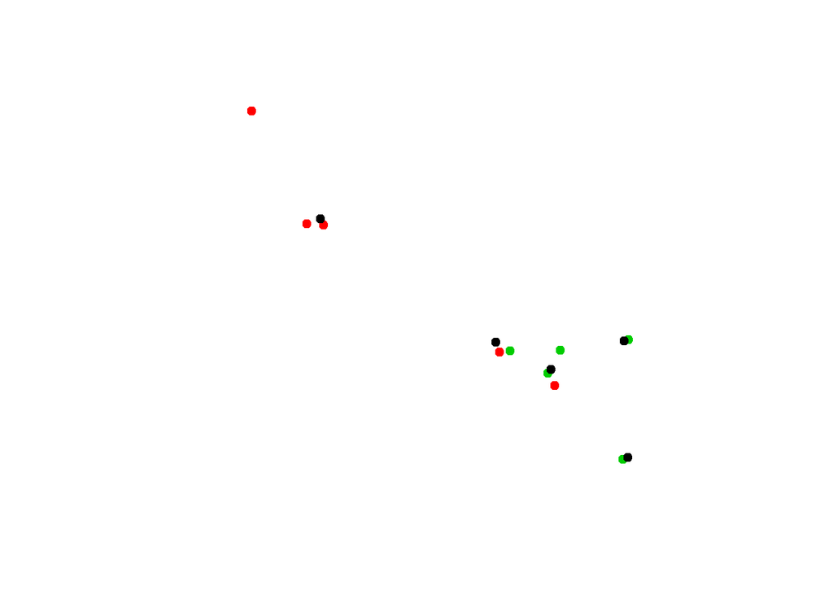

```r
Mgt <- factor(Orch@data$mgmt, labels=c("red", "green", "blue"))
plot(Orch, pch = 19, col = Mgt)
```

Here I’m hiding a breakdown of the abundance of each taxa of interest where I subset the dataset for these bacteria and fungi of interest, then checking how many observations of >0.01 occur…

From this it seems that it might be worth looking at spatial patterns in the good bacteria, Pseudomonas (2) and Bacillus (3), as well as the fungal pathogens, Monilinia (1), Botrytis (2), Mycosphaerella tassiana (3), and Cladosporium (4).

Here we calculate spatial correlograms, to see if the abundance of each pathogen is more similar at closer sites, and at what scales the patchy pattern of spatial autocorrelation might occur. So we check if the data are more similar than expected compared to the rest of the dataset at progressively longer distances (x axis)

```r
library(ncf)
#bacgood2
ncf.cor1 <- correlog(bacgood2$POINT_X, bacgood2$POINT_Y, bacgood2$Abundance, increment=2000, resamp=500)
```

```
## 50  of  500
100  of  500
150  of  500
200  of  500
250  of  500
300  of  500
350  of  500
400  of  500
450  of  500
500  of  500
```

```r
#bacgood3
ncf.cor2 <- correlog(bacgood3$POINT_X, bacgood3$POINT_Y, bacgood3$Abundance, increment=2000, resamp=500)
```

```
## 50  of  500
100  of  500
150  of  500
200  of  500
250  of  500
300  of  500
350  of  500
400  of  500
450  of  500
500  of  500
```

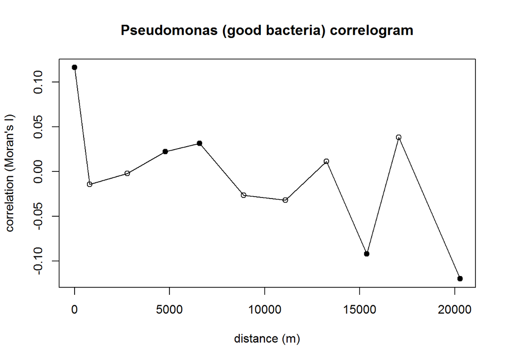

```r
par(mfrow=c(1,1))
plot(ncf.cor1, main="Pseudomonas (good bacteria) correlogram", xlab = "distance (m)", ylab= "correlation (Moran's I)")
```

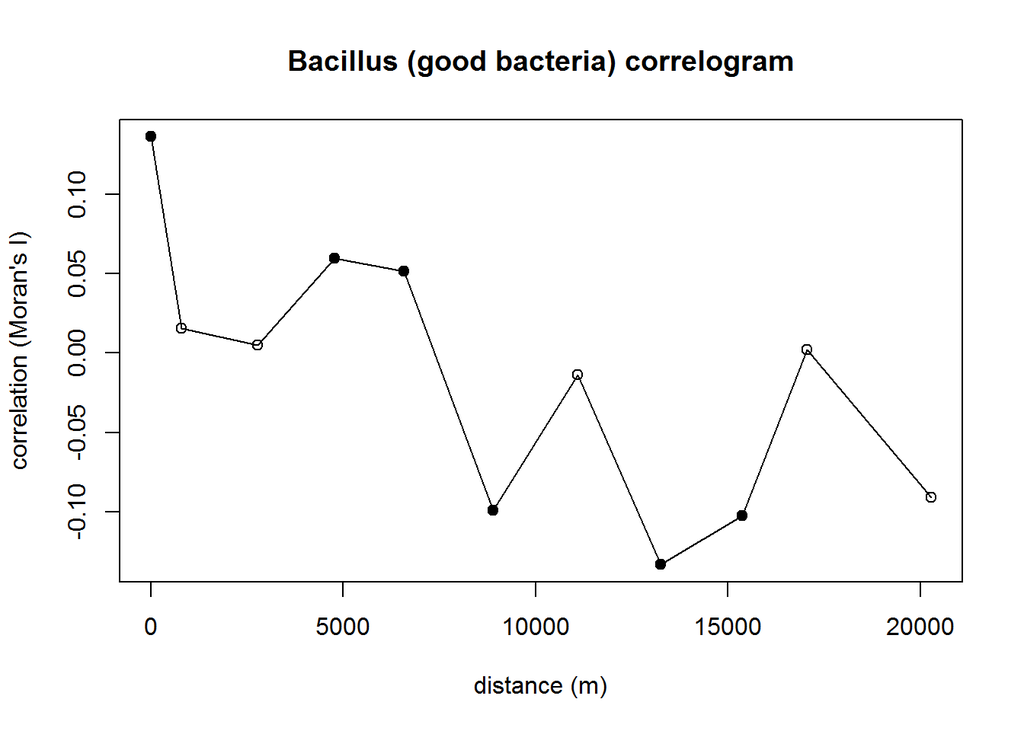

```r
plot(ncf.cor2, main="Bacillus (good bacteria) correlogram", xlab = "distance (m)", ylab= "correlation (Moran's I)")
```

One thing to rememeber is that the longer lag distances are not very interpretable and less meaningful using this statistic because there are less data points separated by the longest distances across the range, and smaller scale patterns of patchiness sometimes produce “harmonics” that look like patterns at larger scales.

```r
#funpath1
ncf.cor3 <- correlog(funpath1$POINT_X, funpath1$POINT_Y, funpath1$Abundance, increment=2000, resamp=500)
```

```
## 50  of  500
100  of  500
150  of  500
200  of  500
250  of  500
300  of  500
350  of  500
400  of  500
450  of  500
500  of  500
```

```r
#funpath2
ncf.cor4 <- correlog(funpath2$POINT_X, funpath2$POINT_Y, funpath2$Abundance, increment=2000, resamp=500)
```

```
## 50  of  500
100  of  500
150  of  500
200  of  500
250  of  500
300  of  500
350  of  500
400  of  500
450  of  500
500  of  500
```

```r
#funpath3
ncf.cor5 <- correlog(funpath3$POINT_X, funpath3$POINT_Y, funpath3$Abundance, increment=2000, resamp=500)
```

```
## 50  of  500
100  of  500
150  of  500
200  of  500
250  of  500
300  of  500
350  of  500
400  of  500
450  of  500
500  of  500
```

```r
#funpath4
ncf.cor6 <- correlog(funpath4$POINT_X, funpath4$POINT_Y, funpath4$Abundance, increment=2000, resamp=500)
```

```
## 50  of  500
100  of  500
150  of  500
200  of  500
250  of  500
300  of  500
350  of  500
400  of  500
450  of  500
500  of  500
```

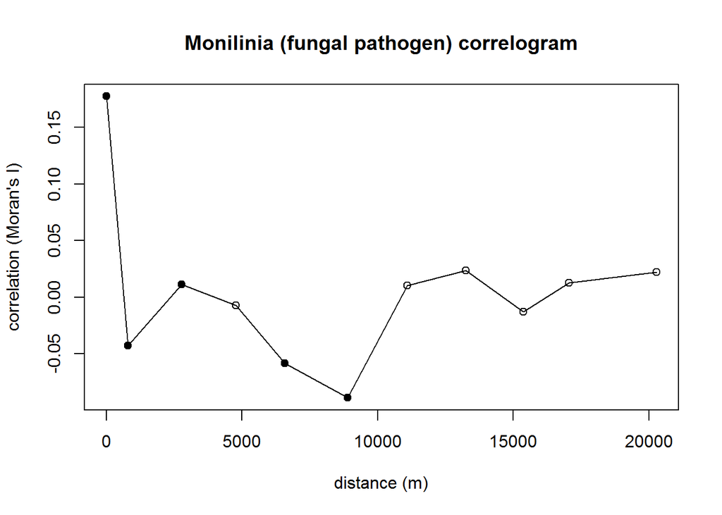

```r
par(mfrow=c(1,1))
plot(ncf.cor3, main="Monilinia (fungal pathogen) correlogram", xlab = "distance (m)", ylab= "correlation (Moran's I)")
```

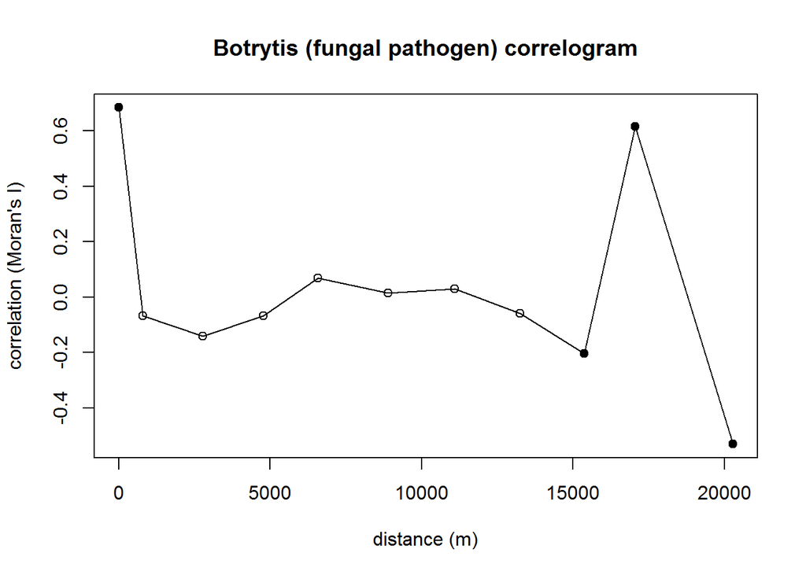

```r
plot(ncf.cor4, main="Botrytis (fungal pathogen) correlogram", xlab = "distance (m)", ylab= "correlation (Moran's I)")
```

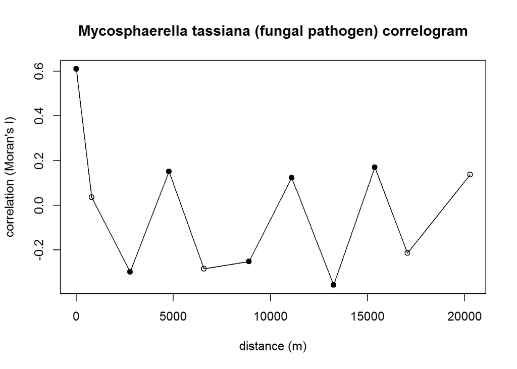

```r
plot(ncf.cor5, main="Mycosphaerella tassiana (fungal pathogen) correlogram", xlab = "distance (m)", ylab= "correlation (Moran's I)")
```

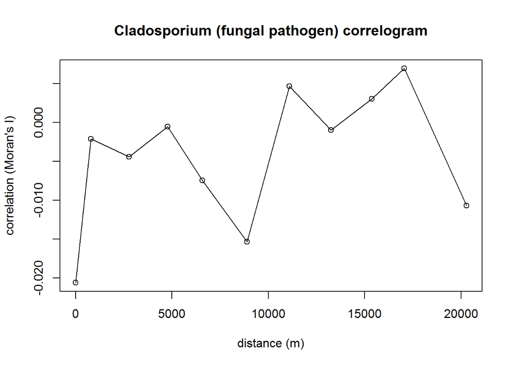

```r
plot(ncf.cor6, main="Cladosporium (fungal pathogen) correlogram", xlab = "distance (m)", ylab= "correlation (Moran's I)")
```

Botrytis and Mycosphaerella tassiana have higher spatial autocorrelation at very short distances (<1km), so perhaps they are more detectable, and locally abundant when they appear.

# What environmental, climatic and farm management related factors underly the distribution of these good and bad bacteria and fungi?

We’ll use **canonical correlation analysis (CCorA)**. Canonical Correlation Analysis is a direct extension of the linear regression framework for multiple independent and multiple dependent variables:

x1 + x2 + x3 + … + xn = y1 + y2 + … + yn

Similar to linear regression - it’s not appropriate to put in a million variables - like a full community dataset. (It’s not the same as canonical correspondence analysis (CCA in vegan) which is more like RDA for community data).

*Note: I split management into two indicator variables for organic and soft management*

```r
goodbacCC<-CCorA(as.matrix(env2),as.matrix(GoodBac2), stand.X=TRUE,stand.Y=TRUE)
goodbacCC
```

```
##
## Canonical Correlation Analysis
##
## Call:
## CCorA(Y = as.matrix(env2), X = as.matrix(GoodBac2), stand.Y = TRUE,      stand.X = TRUE)
##
##               Y X
## Matrix Ranks 11 3
##
## Pillai's trace:  1.577264
##
## Significance of Pillai's trace:
## from F-distribution:   0.02545
##                        CanAxis1 CanAxis2 CanAxis3
## Canonical Correlations  0.93103  0.69438   0.4778
##
##                      Y | X  X | Y
## RDA R squares      0.28610 0.5865
## adj. RDA R squares 0.20373 0.3338
```

```r
summary(goodbacCC)
```

```
##              Length Class  Mode
## Pillai        1     -none- numeric
## Eigenvalues   3     -none- numeric
## CanCorr       3     -none- numeric
## Mat.ranks     2     -none- numeric
## RDA.Rsquares  2     -none- numeric
## RDA.adj.Rsq   2     -none- numeric
## nperm         1     -none- numeric
## p.Pillai      1     -none- numeric
## p.perm        1     -none- logical
## Cy           90     -none- numeric
## Cx           90     -none- numeric
## corr.Y.Cy    33     -none- numeric
## corr.X.Cx     9     -none- numeric
## corr.Y.Cx    33     -none- numeric
## corr.X.Cy     9     -none- numeric
## control      12     how    list
## call          5     -none- call
```

```r
# ... how much the successive canonical variates correlate with each other
goodbacCC$CanCorr
```

```
## [1] 0.9310259 0.6943768 0.4778027
```

```r
#Eigenvalues are canonical correlations squared
print(sum(goodbacCC$CanCorr^2))
```

```
## [1] 1.577264
```

```r
print(sum(goodbacCC$Eigenvalues))
```

```
## [1] 1.577264
```

```r
#Pillai's trace is the sum of squared Canonical correlations
print(goodbacCC$Pillai)
```

```
## [1] 1.577264
```

```r
#...tests whether the canonical correlation analysis is overall significantly different from zero
#... if significant we can proceed
#RDA R squares
goodbacCC
```

```
##
## Canonical Correlation Analysis
##
## Call:
## CCorA(Y = as.matrix(env2), X = as.matrix(GoodBac2), stand.Y = TRUE,      stand.X = TRUE)
##
##               Y X
## Matrix Ranks 11 3
##
## Pillai's trace:  1.577264
##
## Significance of Pillai's trace:
## from F-distribution:   0.02545
##                        CanAxis1 CanAxis2 CanAxis3
## Canonical Correlations  0.93103  0.69438   0.4778
##
##                      Y | X  X | Y
## RDA R squares      0.28610 0.5865
## adj. RDA R squares 0.20373 0.3338
```

```r
print(goodbacCC$RDA.Rsquares)
```

```
## [1] 0.2861043 0.5864708
```

```r
# ...tell you how much variance in the *dependent* variables is explained by the independent *canonical variate* (and vice versa)
# i.e. Y|X = variance in Y variables explained by the X canonical variate
# i.e. X|Y = variance in X variables explained by the Y canonical variate

# IMPORTANT
# corr.Y.Cy = Correlation of each variable in Y with its Canonical variate (similarly, corr.X.Cx)
# Also called Canonical loadings or canonical structure correlations, interpreted as factor loadings
# ...tells you how much do individual variables contribute to their own canonical variates
goodbacCC$corr.Y.Cy
```

```
##              CanAxis1    CanAxis2     CanAxis3
## PCNM1      0.68501732  0.05256714  0.202760641
## PCNM2      0.17416042  0.05188818  0.136070526
## Precip     0.67279330  0.20507752  0.247233229
## MinT      -0.66590516 -0.37163614 -0.282647374
## VPDmin    -0.33666013 -0.23214218 -0.334709884
## VPDmax    -0.01589926 -0.37166124  0.182274372
## PropPear  -0.24163936  0.07031323  0.520269316
## PropFruit -0.40500436 -0.34527129  0.112363504
## PropFor    0.77636574  0.05885555  0.024071757
## soft      -0.38335293 -0.15197504  0.008747529
## org        0.82461582  0.04642124 -0.178293155
```

```r
goodbacCC$corr.X.Cx
```

```
##               CanAxis1    CanAxis2    CanAxis3
## Bacillus     0.9632888 -0.06306438 -0.26095515
## Pantoea     -0.2655232 -0.96393024  0.01832829
## Pseudomonas -0.5341073  0.26610714 -0.80244402
```

```r
# ...NOT THAT INFORMATIVE
# corr.Y.Cx = Correlation of each variable in Y with each Canonical variate in X (similarly corr.X.Cy)
# Also called canonical cross-loading. Correlation of each variabel with the opposite canonical variate
# ...tells you how strongly are individual variables correlated with the canonical variates of the dependent/independent set
goodbacCC$corr.Y.Cx
```

```
##              CanAxis1    CanAxis2     CanAxis3
## PCNM1      0.63776886  0.03650140  0.096879584
## PCNM2      0.16214786  0.03602995  0.065014866
## Precip     0.62638799  0.14240107  0.118128707
## MinT      -0.61997495 -0.25805552 -0.135049681
## VPDmin    -0.31343930 -0.16119414 -0.159925290
## VPDmax    -0.01480262 -0.25807294  0.087091189
## PropPear  -0.22497250  0.04882388  0.248586090
## PropFruit -0.37706955 -0.23974837  0.053687587
## PropFor    0.72281661  0.04086793  0.011501551
## soft      -0.35691151 -0.10552794  0.004179593
## org        0.76773868  0.03223383 -0.085188953
```

```r
goodbacCC$corr.X.Cy
```

```
##               CanAxis1    CanAxis2     CanAxis3
## Bacillus     0.8968468 -0.04379044 -0.124685079
## Pantoea     -0.2472090 -0.66933080  0.008757306
## Pseudomonas -0.4972677  0.18477862 -0.383409928
```

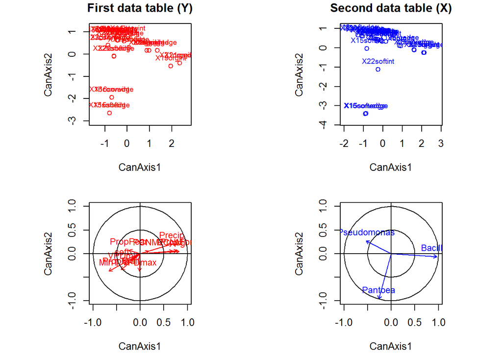

```r
biplot(goodbacCC)
```